# Risk Factor Analysis

## Outcome Variable

**Outcome Variable:** whz

## Predictor Variables

**Intervention Variable:** hfoodsec

**Adjustment Set:**

- arm
- sex
- W_mage
- meducyrs
- feducyrs
- hhwealth_quart
- vagbrth
- W_nrooms
- W_nchldlt5
- brthmon
- W_parity
- impfloor
- impsan
- safeh20
- delta_W_mage
- delta_meducyrs
- delta_feducyrs
- delta_hhwealth_quart
- delta_vagbrth
- delta_W_nrooms
- delta_W_nchldlt5
- delta_brthmon
- delta_W_parity
- delta_impfloor
- delta_impsan
- delta_safeh20

## Stratifying Variables

The analysis was stratified on these variable(s):

- agecat
- studyid
- country

## Data Summary

| agecat | studyid | country | hfoodsec | n_cell | n |
| --- | --- | --- | --- | --- | --- |
| Birth | ki0047075b-MAL-ED | BANGLADESH | Food Secure | 151 | 178 |
| Birth | ki0047075b-MAL-ED | BANGLADESH | Mildly Food Insecure | 3 | 178 |
| Birth | ki0047075b-MAL-ED | BANGLADESH | Food Insecure | 24 | 178 |
| Birth | ki0047075b-MAL-ED | BRAZIL | Food Secure | 0 | 102 |
| Birth | ki0047075b-MAL-ED | BRAZIL | Mildly Food Insecure | 11 | 102 |
| Birth | ki0047075b-MAL-ED | BRAZIL | Food Insecure | 91 | 102 |
| Birth | ki0047075b-MAL-ED | INDIA | Food Secure | 151 | 167 |
| Birth | ki0047075b-MAL-ED | INDIA | Mildly Food Insecure | 2 | 167 |
| Birth | ki0047075b-MAL-ED | INDIA | Food Insecure | 14 | 167 |
| Birth | ki0047075b-MAL-ED | NEPAL | Food Secure | 75 | 96 |
| Birth | ki0047075b-MAL-ED | NEPAL | Mildly Food Insecure | 9 | 96 |
| Birth | ki0047075b-MAL-ED | NEPAL | Food Insecure | 12 | 96 |
| Birth | ki0047075b-MAL-ED | PERU | Food Secure | 26 | 105 |
| Birth | ki0047075b-MAL-ED | PERU | Mildly Food Insecure | 24 | 105 |
| Birth | ki0047075b-MAL-ED | PERU | Food Insecure | 55 | 105 |
| Birth | ki0047075b-MAL-ED | SOUTH AFRICA | Food Secure | 106 | 193 |
| Birth | ki0047075b-MAL-ED | SOUTH AFRICA | Mildly Food Insecure | 17 | 193 |
| Birth | ki0047075b-MAL-ED | SOUTH AFRICA | Food Insecure | 70 | 193 |
| Birth | ki1017093-NIH-Birth | BANGLADESH | Food Secure | 3 | 28 |
| Birth | ki1017093-NIH-Birth | BANGLADESH | Mildly Food Insecure | 21 | 28 |
| Birth | ki1017093-NIH-Birth | BANGLADESH | Food Insecure | 4 | 28 |
| Birth | ki1017093c-NIH-Crypto | BANGLADESH | Food Secure | 14 | 23 |
| Birth | ki1017093c-NIH-Crypto | BANGLADESH | Mildly Food Insecure | 6 | 23 |
| Birth | ki1017093c-NIH-Crypto | BANGLADESH | Food Insecure | 3 | 23 |
| Birth | kiGH5241-JiVitA-3 | BANGLADESH | Food Secure | 4974 | 10289 |
| Birth | kiGH5241-JiVitA-3 | BANGLADESH | Mildly Food Insecure | 3502 | 10289 |
| Birth | kiGH5241-JiVitA-3 | BANGLADESH | Food Insecure | 1813 | 10289 |
| Birth | kiGH5241-JiVitA-4 | BANGLADESH | Food Secure | 334 | 680 |
| Birth | kiGH5241-JiVitA-4 | BANGLADESH | Mildly Food Insecure | 250 | 680 |
| Birth | kiGH5241-JiVitA-4 | BANGLADESH | Food Insecure | 96 | 680 |

[output cut: 66 more lines]

The following strata were considered:

- agecat: 24 months, studyid: ki0047075b-MAL-ED, country: BANGLADESH
- agecat: 24 months, studyid: ki0047075b-MAL-ED, country: BRAZIL
- agecat: 24 months, studyid: ki0047075b-MAL-ED, country: INDIA
- agecat: 24 months, studyid: ki0047075b-MAL-ED, country: NEPAL
- agecat: 24 months, studyid: ki0047075b-MAL-ED, country: PERU
- agecat: 24 months, studyid: ki0047075b-MAL-ED, country: SOUTH AFRICA
- agecat: 24 months, studyid: ki1017093-NIH-Birth, country: BANGLADESH
- agecat: 24 months, studyid: ki1017093c-NIH-Crypto, country: BANGLADESH
- agecat: 24 months, studyid: ki1113344-GMS-Nepal, country: NEPAL
- agecat: 24 months, studyid: kiGH5241-JiVitA-3, country: BANGLADESH
- agecat: 24 months, studyid: kiGH5241-JiVitA-4, country: BANGLADESH
- agecat: 6 months, studyid: ki0047075b-MAL-ED, country: BANGLADESH
- agecat: 6 months, studyid: ki0047075b-MAL-ED, country: BRAZIL
- agecat: 6 months, studyid: ki0047075b-MAL-ED, country: INDIA
- agecat: 6 months, studyid: ki0047075b-MAL-ED, country: NEPAL
- agecat: 6 months, studyid: ki0047075b-MAL-ED, country: PERU
- agecat: 6 months, studyid: ki0047075b-MAL-ED, country: SOUTH AFRICA
- agecat: 6 months, studyid: ki1017093-NIH-Birth, country: BANGLADESH
- agecat: 6 months, studyid: ki1017093c-NIH-Crypto, country: BANGLADESH
- agecat: 6 months, studyid: ki1113344-GMS-Nepal, country: NEPAL
- agecat: 6 months, studyid: kiGH5241-JiVitA-3, country: BANGLADESH
- agecat: 6 months, studyid: kiGH5241-JiVitA-4, country: BANGLADESH
- agecat: Birth, studyid: ki0047075b-MAL-ED, country: BANGLADESH
- agecat: Birth, studyid: ki0047075b-MAL-ED, country: BRAZIL
- agecat: Birth, studyid: ki0047075b-MAL-ED, country: INDIA
- agecat: Birth, studyid: ki0047075b-MAL-ED, country: NEPAL
- agecat: Birth, studyid: ki0047075b-MAL-ED, country: PERU
- agecat: Birth, studyid: ki0047075b-MAL-ED, country: SOUTH AFRICA
- agecat: Birth, studyid: ki1017093-NIH-Birth, country: BANGLADESH
- agecat: Birth, studyid: ki1017093c-NIH-Crypto, country: BANGLADESH
- agecat: Birth, studyid: kiGH5241-JiVitA-3, country: BANGLADESH
- agecat: Birth, studyid: kiGH5241-JiVitA-4, country: BANGLADESH

### Dropped Strata

Some strata were dropped due to rare outcomes:

- agecat: Birth, studyid: ki0047075b-MAL-ED, country: BANGLADESH
- agecat: Birth, studyid: ki0047075b-MAL-ED, country: BRAZIL
- agecat: Birth, studyid: ki0047075b-MAL-ED, country: INDIA
- agecat: Birth, studyid: ki1017093-NIH-Birth, country: BANGLADESH
- agecat: Birth, studyid: ki1017093c-NIH-Crypto, country: BANGLADESH
- agecat: 6 months, studyid: ki0047075b-MAL-ED, country: BANGLADESH
- agecat: 6 months, studyid: ki0047075b-MAL-ED, country: BRAZIL
- agecat: 24 months, studyid: ki0047075b-MAL-ED, country: BANGLADESH
- agecat: 24 months, studyid: ki0047075b-MAL-ED, country: BRAZIL

## Methods Detail

We’re interested in the causal parameters $E[Y_a]$ for all values of $a \in \mathcal{A}$. These parameters represent the mean outcome if, possibly contrary to fact, we intervened to set all units to have $A=a$. Under the randomization and positivity assumptions, these are identified by the statistical parameters $\psi_a=E_W[E_{Y|A,W}(Y|A=a,W)]$. In addition, we’re interested in the mean of $Y$, $E[Y]$ under no intervention (the observed mean). We will estimate these parameters by using SuperLearner to fit the relevant likelihood factors – $E_{Y|A,W}(Y|A=a,W)$ and $p(A=a|W)$, and then updating our likelihood fit using a joint TMLE.

For unadjusted analyses ($W=\{\}$), initial likelihoods were estimated using Lrnr_glm to estimate the simple $E(Y|A)$ and Lrnr_mean to estimate $p(A)$. For adjusted analyses, a small library containing Lrnr_glmnet, Lrnr_xgboost, and Lrnr_mean was used.

Having estimated these parameters, we will then use the delta method to estimate relative risks and attributable risks relative to a prespecified baseline level of $A$.

# Results Detail

## Results Plots

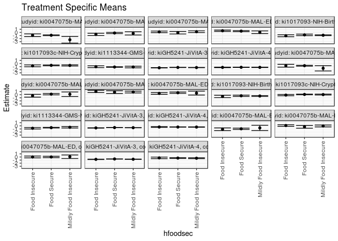

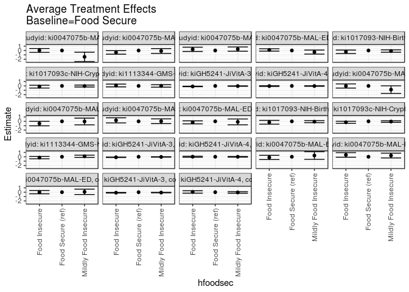

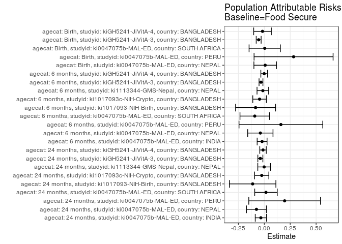

## Results Table

### Parameter: TSM

| agecat | studyid | country | intervention_level | baseline_level | estimate | ci_lower | ci_upper |
| --- | --- | --- | --- | --- | --- | --- | --- |
| Birth | ki0047075b-MAL-ED | NEPAL | Food Secure | NA | -0.9589333 | -1.1679562 | -0.7499105 |
| Birth | ki0047075b-MAL-ED | NEPAL | Mildly Food Insecure | NA | -0.6700000 | -1.5216911 | 0.1816911 |
| Birth | ki0047075b-MAL-ED | NEPAL | Food Insecure | NA | -1.1066667 | -1.5431611 | -0.6701723 |
| Birth | ki0047075b-MAL-ED | PERU | Food Secure | NA | -0.3221724 | -0.7751180 | 0.1307731 |
| Birth | ki0047075b-MAL-ED | PERU | Mildly Food Insecure | NA | -0.0428018 | -0.3438507 | 0.2582471 |
| Birth | ki0047075b-MAL-ED | PERU | Food Insecure | NA | 0.0948097 | -0.1619356 | 0.3515551 |
| Birth | ki0047075b-MAL-ED | SOUTH AFRICA | Food Secure | NA | -0.0004950 | -0.2205181 | 0.2195281 |
| Birth | ki0047075b-MAL-ED | SOUTH AFRICA | Mildly Food Insecure | NA | 0.0801856 | -0.4863049 | 0.6466761 |
| Birth | ki0047075b-MAL-ED | SOUTH AFRICA | Food Insecure | NA | 0.0053890 | -0.2909583 | 0.3017363 |
| Birth | kiGH5241-JiVitA-3 | BANGLADESH | Food Secure | NA | -0.6448516 | -0.6789965 | -0.6107066 |
| Birth | kiGH5241-JiVitA-3 | BANGLADESH | Mildly Food Insecure | NA | -0.7323320 | -0.7725660 | -0.6920981 |
| Birth | kiGH5241-JiVitA-3 | BANGLADESH | Food Insecure | NA | -0.7683434 | -0.8216952 | -0.7149915 |
| Birth | kiGH5241-JiVitA-4 | BANGLADESH | Food Secure | NA | -0.3508182 | -0.4692468 | -0.2323896 |
| Birth | kiGH5241-JiVitA-4 | BANGLADESH | Mildly Food Insecure | NA | -0.4057256 | -0.5378840 | -0.2735671 |
| Birth | kiGH5241-JiVitA-4 | BANGLADESH | Food Insecure | NA | -0.2951639 | -0.5469854 | -0.0433424 |
| 6 months | ki0047075b-MAL-ED | INDIA | Food Secure | NA | -0.6943421 | -0.8349961 | -0.5536881 |
| 6 months | ki0047075b-MAL-ED | INDIA | Mildly Food Insecure | NA | -1.5420000 | -2.3989104 | -0.6850896 |
| 6 months | ki0047075b-MAL-ED | INDIA | Food Insecure | NA | -0.7090196 | -1.1598311 | -0.2582081 |
| 6 months | ki0047075b-MAL-ED | NEPAL | Food Secure | NA | 0.1669326 | -0.0528020 | 0.3866673 |
| 6 months | ki0047075b-MAL-ED | NEPAL | Mildly Food Insecure | NA | 0.1327189 | -0.6014984 | 0.8669361 |
| 6 months | ki0047075b-MAL-ED | NEPAL | Food Insecure | NA | -0.3387842 | -0.7951499 | 0.1175815 |
| 6 months | ki0047075b-MAL-ED | PERU | Food Secure | NA | 0.8189240 | 0.3638698 | 1.2739781 |
| 6 months | ki0047075b-MAL-ED | PERU | Mildly Food Insecure | NA | 0.8412980 | 0.5456183 | 1.1369777 |
| 6 months | ki0047075b-MAL-ED | PERU | Food Insecure | NA | 1.0461272 | 0.6827043 | 1.4095502 |
| 6 months | ki0047075b-MAL-ED | SOUTH AFRICA | Food Secure | NA | 0.6343919 | 0.4190525 | 0.8497313 |
| 6 months | ki0047075b-MAL-ED | SOUTH AFRICA | Mildly Food Insecure | NA | 0.5090302 | -0.1256521 | 1.1437124 |
| 6 months | ki0047075b-MAL-ED | SOUTH AFRICA | Food Insecure | NA | 0.4080520 | 0.1359139 | 0.6801900 |
| 6 months | ki1017093-NIH-Birth | BANGLADESH | Food Secure | NA | -0.3546445 | -0.5565691 | -0.1527200 |
| 6 months | ki1017093-NIH-Birth | BANGLADESH | Mildly Food Insecure | NA | -0.4302917 | -0.5333520 | -0.3272314 |
| 6 months | ki1017093-NIH-Birth | BANGLADESH | Food Insecure | NA | -0.5638084 | -0.9504465 | -0.1771704 |
| 6 months | ki1017093c-NIH-Crypto | BANGLADESH | Food Secure | NA | 0.0753906 | -0.0304826 | 0.1812638 |
| 6 months | ki1017093c-NIH-Crypto | BANGLADESH | Mildly Food Insecure | NA | 0.0286390 | -0.1219832 | 0.1792613 |
| 6 months | ki1017093c-NIH-Crypto | BANGLADESH | Food Insecure | NA | -0.1392050 | -0.3389622 | 0.0605522 |
| 6 months | ki1113344-GMS-Nepal | NEPAL | Food Secure | NA | -0.5886487 | -0.6968810 | -0.4804163 |
| 6 months | ki1113344-GMS-Nepal | NEPAL | Mildly Food Insecure | NA | -0.4762235 | -0.7035487 | -0.2488983 |
| 6 months | ki1113344-GMS-Nepal | NEPAL | Food Insecure | NA | -0.7878018 | -1.0322360 | -0.5433676 |
| 6 months | kiGH5241-JiVitA-3 | BANGLADESH | Food Secure | NA | -0.5612327 | -0.5889148 | -0.5335506 |
| 6 months | kiGH5241-JiVitA-3 | BANGLADESH | Mildly Food Insecure | NA | -0.5998916 | -0.6309058 | -0.5688773 |
| 6 months | kiGH5241-JiVitA-3 | BANGLADESH | Food Insecure | NA | -0.6774259 | -0.7248879 | -0.6299639 |
| 6 months | kiGH5241-JiVitA-4 | BANGLADESH | Food Secure | NA | -0.3884593 | -0.4369858 | -0.3399328 |
| 6 months | kiGH5241-JiVitA-4 | BANGLADESH | Mildly Food Insecure | NA | -0.3960916 | -0.4546186 | -0.3375646 |
| 6 months | kiGH5241-JiVitA-4 | BANGLADESH | Food Insecure | NA | -0.3783091 | -0.4895514 | -0.2670669 |
| 24 months | ki0047075b-MAL-ED | INDIA | Food Secure | NA | -0.9263947 | -1.0447734 | -0.8080160 |
| 24 months | ki0047075b-MAL-ED | INDIA | Mildly Food Insecure | NA | -2.3840000 | -3.4554070 | -1.3125930 |
| 24 months | ki0047075b-MAL-ED | INDIA | Food Insecure | NA | -0.9111765 | -1.3418053 | -0.4805476 |
| 24 months | ki0047075b-MAL-ED | NEPAL | Food Secure | NA | -0.1999795 | -0.4014422 | 0.0014833 |
| 24 months | ki0047075b-MAL-ED | NEPAL | Mildly Food Insecure | NA | -0.3167276 | -0.8309959 | 0.1975407 |
| 24 months | ki0047075b-MAL-ED | NEPAL | Food Insecure | NA | -0.6356563 | -0.9927875 | -0.2785251 |
| 24 months | ki0047075b-MAL-ED | PERU | Food Secure | NA | -0.0983182 | -0.5039306 | 0.3072943 |
| 24 months | ki0047075b-MAL-ED | PERU | Mildly Food Insecure | NA | 0.2199050 | -0.0563854 | 0.4961954 |
| 24 months | ki0047075b-MAL-ED | PERU | Food Insecure | NA | 0.1691770 | -0.0924528 | 0.4308068 |
| 24 months | ki0047075b-MAL-ED | SOUTH AFRICA | Food Secure | NA | 0.4102974 | 0.2461430 | 0.5744519 |
| 24 months | ki0047075b-MAL-ED | SOUTH AFRICA | Mildly Food Insecure | NA | 0.0504798 | -0.3820015 | 0.4829611 |
| 24 months | ki0047075b-MAL-ED | SOUTH AFRICA | Food Insecure | NA | 0.5296545 | 0.3200946 | 0.7392145 |
| 24 months | ki1017093-NIH-Birth | BANGLADESH | Food Secure | NA | -0.7990663 | -1.0411727 | -0.5569598 |
| 24 months | ki1017093-NIH-Birth | BANGLADESH | Mildly Food Insecure | NA | -0.9181150 | -1.0326606 | -0.8035693 |
| 24 months | ki1017093-NIH-Birth | BANGLADESH | Food Insecure | NA | -1.0969741 | -1.4184053 | -0.7755429 |
| 24 months | ki1017093c-NIH-Crypto | BANGLADESH | Food Secure | NA | -0.5855334 | -0.7109664 | -0.4601005 |
| 24 months | ki1017093c-NIH-Crypto | BANGLADESH | Mildly Food Insecure | NA | -0.6118127 | -0.7912012 | -0.4324242 |
| 24 months | ki1017093c-NIH-Crypto | BANGLADESH | Food Insecure | NA | -0.7468916 | -1.0420763 | -0.4517069 |
| 24 months | ki1113344-GMS-Nepal | NEPAL | Food Secure | NA | -1.1240596 | -1.2293490 | -1.0187702 |
| 24 months | ki1113344-GMS-Nepal | NEPAL | Mildly Food Insecure | NA | -1.1268057 | -1.3910175 | -0.8625939 |
| 24 months | ki1113344-GMS-Nepal | NEPAL | Food Insecure | NA | -1.0259541 | -1.3227919 | -0.7291164 |
| 24 months | kiGH5241-JiVitA-3 | BANGLADESH | Food Secure | NA | -1.2608258 | -1.2941694 | -1.2274822 |
| 24 months | kiGH5241-JiVitA-3 | BANGLADESH | Mildly Food Insecure | NA | -1.2968276 | -1.3382768 | -1.2553783 |
| 24 months | kiGH5241-JiVitA-3 | BANGLADESH | Food Insecure | NA | -1.3771131 | -1.4302045 | -1.3240216 |
| 24 months | kiGH5241-JiVitA-4 | BANGLADESH | Food Secure | NA | -1.2120138 | -1.2565885 | -1.1674390 |
| 24 months | kiGH5241-JiVitA-4 | BANGLADESH | Mildly Food Insecure | NA | -1.2334095 | -1.2887728 | -1.1780462 |
| 24 months | kiGH5241-JiVitA-4 | BANGLADESH | Food Insecure | NA | -1.2473124 | -1.3282905 | -1.1663343 |

### Parameter: E(Y)

| agecat | studyid | country | intervention_level | baseline_level | estimate | ci_lower | ci_upper |
| --- | --- | --- | --- | --- | --- | --- | --- |
| Birth | ki0047075b-MAL-ED | NEPAL | NA | NA | -0.9503125 | -1.1412124 | -0.7594126 |
| Birth | ki0047075b-MAL-ED | PERU | NA | NA | -0.0395238 | -0.2249300 | 0.1458824 |
| Birth | ki0047075b-MAL-ED | SOUTH AFRICA | NA | NA | 0.0036788 | -0.1626160 | 0.1699735 |
| Birth | kiGH5241-JiVitA-3 | BANGLADESH | NA | NA | -0.6992565 | -0.7232731 | -0.6752399 |
| Birth | kiGH5241-JiVitA-4 | BANGLADESH | NA | NA | -0.3680294 | -0.4489214 | -0.2871374 |
| 6 months | ki0047075b-MAL-ED | INDIA | NA | NA | -0.7155110 | -0.8495147 | -0.5815073 |
| 6 months | ki0047075b-MAL-ED | NEPAL | NA | NA | 0.1289063 | -0.0638567 | 0.3216692 |
| 6 months | ki0047075b-MAL-ED | PERU | NA | NA | 0.9790991 | 0.7644567 | 1.1937415 |
| 6 months | ki0047075b-MAL-ED | SOUTH AFRICA | NA | NA | 0.5422442 | 0.3806254 | 0.7038629 |
| 6 months | ki1017093-NIH-Birth | BANGLADESH | NA | NA | -0.4389101 | -0.5279432 | -0.3498771 |
| 6 months | ki1017093c-NIH-Crypto | BANGLADESH | NA | NA | 0.0297622 | -0.0491685 | 0.1086930 |
| 6 months | ki1113344-GMS-Nepal | NEPAL | NA | NA | -0.6028654 | -0.6902793 | -0.5154516 |
| 6 months | kiGH5241-JiVitA-3 | BANGLADESH | NA | NA | -0.5932301 | -0.6127836 | -0.5736767 |
| 6 months | kiGH5241-JiVitA-4 | BANGLADESH | NA | NA | -0.3895527 | -0.4270314 | -0.3520739 |
| 24 months | ki0047075b-MAL-ED | INDIA | NA | NA | -0.9595519 | -1.0781202 | -0.8409836 |
| 24 months | ki0047075b-MAL-ED | NEPAL | NA | NA | -0.2757812 | -0.4379560 | -0.1136065 |
| 24 months | ki0047075b-MAL-ED | PERU | NA | NA | 0.0979907 | -0.0798724 | 0.2758537 |
| 24 months | ki0047075b-MAL-ED | SOUTH AFRICA | NA | NA | 0.4264693 | 0.3032402 | 0.5496984 |
| 24 months | ki1017093-NIH-Birth | BANGLADESH | NA | NA | -0.9115790 | -1.0095022 | -0.8136559 |
| 24 months | ki1017093c-NIH-Crypto | BANGLADESH | NA | NA | -0.6103502 | -0.7050157 | -0.5156847 |
| 24 months | ki1113344-GMS-Nepal | NEPAL | NA | NA | -1.1257803 | -1.2146168 | -1.0369438 |
| 24 months | kiGH5241-JiVitA-3 | BANGLADESH | NA | NA | -1.2988352 | -1.3224626 | -1.2752078 |
| 24 months | kiGH5241-JiVitA-4 | BANGLADESH | NA | NA | -1.2243590 | -1.2566569 | -1.1920612 |

### Parameter: ATE

| agecat | studyid | country | intervention_level | baseline_level | estimate | ci_lower | ci_upper |
| --- | --- | --- | --- | --- | --- | --- | --- |
| Birth | ki0047075b-MAL-ED | NEPAL | Food Secure | Food Secure | 0.0000000 | 0.0000000 | 0.0000000 |
| Birth | ki0047075b-MAL-ED | NEPAL | Mildly Food Insecure | Food Secure | 0.2889333 | -0.5880320 | 1.1658987 |
| Birth | ki0047075b-MAL-ED | NEPAL | Food Insecure | Food Secure | -0.1477333 | -0.6316940 | 0.3362273 |
| Birth | ki0047075b-MAL-ED | PERU | Food Secure | Food Secure | 0.0000000 | 0.0000000 | 0.0000000 |
| Birth | ki0047075b-MAL-ED | PERU | Mildly Food Insecure | Food Secure | 0.2793706 | -0.2669278 | 0.8256690 |
| Birth | ki0047075b-MAL-ED | PERU | Food Insecure | Food Secure | 0.4169822 | -0.1063327 | 0.9402971 |
| Birth | ki0047075b-MAL-ED | SOUTH AFRICA | Food Secure | Food Secure | 0.0000000 | 0.0000000 | 0.0000000 |
| Birth | ki0047075b-MAL-ED | SOUTH AFRICA | Mildly Food Insecure | Food Secure | 0.0806806 | -0.5272390 | 0.6886002 |
| Birth | ki0047075b-MAL-ED | SOUTH AFRICA | Food Insecure | Food Secure | 0.0058840 | -0.3624049 | 0.3741729 |
| Birth | kiGH5241-JiVitA-3 | BANGLADESH | Food Secure | Food Secure | 0.0000000 | 0.0000000 | 0.0000000 |
| Birth | kiGH5241-JiVitA-3 | BANGLADESH | Mildly Food Insecure | Food Secure | -0.0874805 | -0.1384249 | -0.0365361 |
| Birth | kiGH5241-JiVitA-3 | BANGLADESH | Food Insecure | Food Secure | -0.1234918 | -0.1847982 | -0.0621853 |
| Birth | kiGH5241-JiVitA-4 | BANGLADESH | Food Secure | Food Secure | 0.0000000 | 0.0000000 | 0.0000000 |
| Birth | kiGH5241-JiVitA-4 | BANGLADESH | Mildly Food Insecure | Food Secure | -0.0549074 | -0.2338682 | 0.1240534 |
| Birth | kiGH5241-JiVitA-4 | BANGLADESH | Food Insecure | Food Secure | 0.0556542 | -0.2221864 | 0.3334948 |
| 6 months | ki0047075b-MAL-ED | INDIA | Food Secure | Food Secure | 0.0000000 | 0.0000000 | 0.0000000 |
| 6 months | ki0047075b-MAL-ED | INDIA | Mildly Food Insecure | Food Secure | -0.8476579 | -1.7160351 | 0.0207193 |
| 6 months | ki0047075b-MAL-ED | INDIA | Food Insecure | Food Secure | -0.0146775 | -0.4869217 | 0.4575667 |
| 6 months | ki0047075b-MAL-ED | NEPAL | Food Secure | Food Secure | 0.0000000 | 0.0000000 | 0.0000000 |
| 6 months | ki0047075b-MAL-ED | NEPAL | Mildly Food Insecure | Food Secure | -0.0342138 | -0.8014435 | 0.7330160 |
| 6 months | ki0047075b-MAL-ED | NEPAL | Food Insecure | Food Secure | -0.5057169 | -1.0143206 | 0.0028869 |
| 6 months | ki0047075b-MAL-ED | PERU | Food Secure | Food Secure | 0.0000000 | 0.0000000 | 0.0000000 |
| 6 months | ki0047075b-MAL-ED | PERU | Mildly Food Insecure | Food Secure | 0.0223740 | -0.5205502 | 0.5652982 |
| 6 months | ki0047075b-MAL-ED | PERU | Food Insecure | Food Secure | 0.2272033 | -0.3577767 | 0.8121833 |
| 6 months | ki0047075b-MAL-ED | SOUTH AFRICA | Food Secure | Food Secure | 0.0000000 | 0.0000000 | 0.0000000 |
| 6 months | ki0047075b-MAL-ED | SOUTH AFRICA | Mildly Food Insecure | Food Secure | -0.1253618 | -0.7953281 | 0.5446045 |
| 6 months | ki0047075b-MAL-ED | SOUTH AFRICA | Food Insecure | Food Secure | -0.2263399 | -0.5737815 | 0.1211016 |
| 6 months | ki1017093-NIH-Birth | BANGLADESH | Food Secure | Food Secure | 0.0000000 | 0.0000000 | 0.0000000 |
| 6 months | ki1017093-NIH-Birth | BANGLADESH | Mildly Food Insecure | Food Secure | -0.0756472 | -0.3029423 | 0.1516479 |
| 6 months | ki1017093-NIH-Birth | BANGLADESH | Food Insecure | Food Secure | -0.2091639 | -0.6457660 | 0.2274382 |
| 6 months | ki1017093c-NIH-Crypto | BANGLADESH | Food Secure | Food Secure | 0.0000000 | 0.0000000 | 0.0000000 |
| 6 months | ki1017093c-NIH-Crypto | BANGLADESH | Mildly Food Insecure | Food Secure | -0.0467515 | -0.2309339 | 0.1374308 |
| 6 months | ki1017093c-NIH-Crypto | BANGLADESH | Food Insecure | Food Secure | -0.2145956 | -0.4408682 | 0.0116770 |
| 6 months | ki1113344-GMS-Nepal | NEPAL | Food Secure | Food Secure | 0.0000000 | 0.0000000 | 0.0000000 |
| 6 months | ki1113344-GMS-Nepal | NEPAL | Mildly Food Insecure | Food Secure | 0.1124252 | -0.1394537 | 0.3643041 |
| 6 months | ki1113344-GMS-Nepal | NEPAL | Food Insecure | Food Secure | -0.1991531 | -0.4665552 | 0.0682489 |
| 6 months | kiGH5241-JiVitA-3 | BANGLADESH | Food Secure | Food Secure | 0.0000000 | 0.0000000 | 0.0000000 |
| 6 months | kiGH5241-JiVitA-3 | BANGLADESH | Mildly Food Insecure | Food Secure | -0.0386588 | -0.0795271 | 0.0022094 |
| 6 months | kiGH5241-JiVitA-3 | BANGLADESH | Food Insecure | Food Secure | -0.1161932 | -0.1690865 | -0.0632999 |
| 6 months | kiGH5241-JiVitA-4 | BANGLADESH | Food Secure | Food Secure | 0.0000000 | 0.0000000 | 0.0000000 |
| 6 months | kiGH5241-JiVitA-4 | BANGLADESH | Mildly Food Insecure | Food Secure | -0.0076323 | -0.0795138 | 0.0642493 |
| 6 months | kiGH5241-JiVitA-4 | BANGLADESH | Food Insecure | Food Secure | 0.0101502 | -0.1079065 | 0.1282068 |
| 24 months | ki0047075b-MAL-ED | INDIA | Food Secure | Food Secure | 0.0000000 | 0.0000000 | 0.0000000 |
| 24 months | ki0047075b-MAL-ED | INDIA | Mildly Food Insecure | Food Secure | -1.4576053 | -2.5355322 | -0.3796783 |
| 24 months | ki0047075b-MAL-ED | INDIA | Food Insecure | Food Secure | 0.0152183 | -0.4313853 | 0.4618218 |
| 24 months | ki0047075b-MAL-ED | NEPAL | Food Secure | Food Secure | 0.0000000 | 0.0000000 | 0.0000000 |
| 24 months | ki0047075b-MAL-ED | NEPAL | Mildly Food Insecure | Food Secure | -0.1167482 | -0.6708601 | 0.4373637 |
| 24 months | ki0047075b-MAL-ED | NEPAL | Food Insecure | Food Secure | -0.4356769 | -0.8435846 | -0.0277691 |
| 24 months | ki0047075b-MAL-ED | PERU | Food Secure | Food Secure | 0.0000000 | 0.0000000 | 0.0000000 |
| 24 months | ki0047075b-MAL-ED | PERU | Mildly Food Insecure | Food Secure | 0.3182232 | -0.1687811 | 0.8052275 |
| 24 months | ki0047075b-MAL-ED | PERU | Food Insecure | Food Secure | 0.2674952 | -0.2215632 | 0.7565536 |
| 24 months | ki0047075b-MAL-ED | SOUTH AFRICA | Food Secure | Food Secure | 0.0000000 | 0.0000000 | 0.0000000 |
| 24 months | ki0047075b-MAL-ED | SOUTH AFRICA | Mildly Food Insecure | Food Secure | -0.3598176 | -0.8226927 | 0.1030574 |
| 24 months | ki0047075b-MAL-ED | SOUTH AFRICA | Food Insecure | Food Secure | 0.1193571 | -0.1469178 | 0.3856320 |
| 24 months | ki1017093-NIH-Birth | BANGLADESH | Food Secure | Food Secure | 0.0000000 | 0.0000000 | 0.0000000 |
| 24 months | ki1017093-NIH-Birth | BANGLADESH | Mildly Food Insecure | Food Secure | -0.1190487 | -0.3871400 | 0.1490425 |
| 24 months | ki1017093-NIH-Birth | BANGLADESH | Food Insecure | Food Secure | -0.2979078 | -0.7006300 | 0.1048144 |
| 24 months | ki1017093c-NIH-Crypto | BANGLADESH | Food Secure | Food Secure | 0.0000000 | 0.0000000 | 0.0000000 |
| 24 months | ki1017093c-NIH-Crypto | BANGLADESH | Mildly Food Insecure | Food Secure | -0.0262793 | -0.2437826 | 0.1912240 |
| 24 months | ki1017093c-NIH-Crypto | BANGLADESH | Food Insecure | Food Secure | -0.1613582 | -0.4812546 | 0.1585383 |
| 24 months | ki1113344-GMS-Nepal | NEPAL | Food Secure | Food Secure | 0.0000000 | 0.0000000 | 0.0000000 |
| 24 months | ki1113344-GMS-Nepal | NEPAL | Mildly Food Insecure | Food Secure | -0.0027462 | -0.2875348 | 0.2820424 |
| 24 months | ki1113344-GMS-Nepal | NEPAL | Food Insecure | Food Secure | 0.0981054 | -0.2173420 | 0.4135529 |
| 24 months | kiGH5241-JiVitA-3 | BANGLADESH | Food Secure | Food Secure | 0.0000000 | 0.0000000 | 0.0000000 |
| 24 months | kiGH5241-JiVitA-3 | BANGLADESH | Mildly Food Insecure | Food Secure | -0.0360018 | -0.0880219 | 0.0160184 |
| 24 months | kiGH5241-JiVitA-3 | BANGLADESH | Food Insecure | Food Secure | -0.1162872 | -0.1775625 | -0.0550120 |
| 24 months | kiGH5241-JiVitA-4 | BANGLADESH | Food Secure | Food Secure | 0.0000000 | 0.0000000 | 0.0000000 |
| 24 months | kiGH5241-JiVitA-4 | BANGLADESH | Mildly Food Insecure | Food Secure | -0.0213957 | -0.0916864 | 0.0488949 |
| 24 months | kiGH5241-JiVitA-4 | BANGLADESH | Food Insecure | Food Secure | -0.0352987 | -0.1279199 | 0.0573225 |

### Parameter: PAR

| agecat | studyid | country | intervention_level | baseline_level | estimate | ci_lower | ci_upper |
| --- | --- | --- | --- | --- | --- | --- | --- |
| Birth | ki0047075b-MAL-ED | NEPAL | Food Secure | NA | 0.0086208 | -0.1003141 | 0.1175558 |
| Birth | ki0047075b-MAL-ED | PERU | Food Secure | NA | 0.2826486 | -0.0987179 | 0.6640151 |
| Birth | ki0047075b-MAL-ED | SOUTH AFRICA | Food Secure | NA | 0.0041737 | -0.1468025 | 0.1551500 |
| Birth | kiGH5241-JiVitA-3 | BANGLADESH | Food Secure | NA | -0.0544049 | -0.0781510 | -0.0306588 |
| Birth | kiGH5241-JiVitA-4 | BANGLADESH | Food Secure | NA | -0.0172112 | -0.1023438 | 0.0679213 |
| 6 months | ki0047075b-MAL-ED | INDIA | Food Secure | NA | -0.0211689 | -0.0689128 | 0.0265750 |
| 6 months | ki0047075b-MAL-ED | NEPAL | Food Secure | NA | -0.0380264 | -0.1600971 | 0.0840444 |
| 6 months | ki0047075b-MAL-ED | PERU | Food Secure | NA | 0.1601751 | -0.2440463 | 0.5643966 |
| 6 months | ki0047075b-MAL-ED | SOUTH AFRICA | Food Secure | NA | -0.0921478 | -0.2346371 | 0.0503416 |
| 6 months | ki1017093-NIH-Birth | BANGLADESH | Food Secure | NA | -0.0842656 | -0.2771889 | 0.1086576 |
| 6 months | ki1017093c-NIH-Crypto | BANGLADESH | Food Secure | NA | -0.0456284 | -0.1110894 | 0.0198327 |
| 6 months | ki1113344-GMS-Nepal | NEPAL | Food Secure | NA | -0.0142168 | -0.0701998 | 0.0417662 |
| 6 months | kiGH5241-JiVitA-3 | BANGLADESH | Food Secure | NA | -0.0319974 | -0.0506195 | -0.0133753 |
| 6 months | kiGH5241-JiVitA-4 | BANGLADESH | Food Secure | NA | -0.0010934 | -0.0334107 | 0.0312240 |
| 24 months | ki0047075b-MAL-ED | INDIA | Food Secure | NA | -0.0331571 | -0.0875022 | 0.0211879 |
| 24 months | ki0047075b-MAL-ED | NEPAL | Food Secure | NA | -0.0758018 | -0.1721363 | 0.0205328 |
| 24 months | ki0047075b-MAL-ED | PERU | Food Secure | NA | 0.1963088 | -0.1496157 | 0.5422334 |
| 24 months | ki0047075b-MAL-ED | SOUTH AFRICA | Food Secure | NA | 0.0161719 | -0.0924512 | 0.1247949 |
| 24 months | ki1017093-NIH-Birth | BANGLADESH | Food Secure | NA | -0.1125128 | -0.3369284 | 0.1119028 |
| 24 months | ki1017093c-NIH-Crypto | BANGLADESH | Food Secure | NA | -0.0248168 | -0.0936994 | 0.0440659 |
| 24 months | ki1113344-GMS-Nepal | NEPAL | Food Secure | NA | -0.0017207 | -0.0627759 | 0.0593344 |
| 24 months | kiGH5241-JiVitA-3 | BANGLADESH | Food Secure | NA | -0.0380094 | -0.0622072 | -0.0138115 |
| 24 months | kiGH5241-JiVitA-4 | BANGLADESH | Food Secure | NA | -0.0123453 | -0.0435695 | 0.0188790 |